# IE6600 Project 1 Group 7 U.S. Chronic Disease Indicators

## Aditi Vivek Kulkarni, Anoushka Karan Pakhare, Ebube Onwusika

### Data Acquisition and Inspection:

```python
import pandas as pd
import matplotlib.pyplot as plt

df= pd.read_csv("U.S._Chronic_Disease_Indicators.csv")
df.head()
```

|  | YearStart | YearEnd | LocationAbbr | LocationDesc | DataSource | Topic | Question | Response | DataValueUnit | DataValueType | ... | TopicID | QuestionID | ResponseID | DataValueTypeID | StratificationCategoryID1 | StratificationID1 | StratificationCategoryID2 | StratificationID2 | StratificationCategoryID3 | StratificationID3 |
| --- | --- | --- | --- | --- | --- | --- | --- | --- | --- | --- | --- | --- | --- | --- | --- | --- | --- | --- | --- | --- | --- |
| 0 | 2020 | 2020 | US | United States | BRFSS | Health Status | Recent activity limitation among adults | NaN | Number | Age-adjusted Mean | ... | HEA | HEA04 | NaN | AGEADJMEAN | SEX | SEXF | NaN | NaN | NaN | NaN |
| 1 | 2015 | 2019 | AR | Arkansas | US Cancer DVT | Cancer | Invasive cancer (all sites combined), incidence | NaN | Number | Number | ... | CAN | CAN07 | NaN | NMBR | SEX | SEXM | NaN | NaN | NaN | NaN |
| 2 | 2015 | 2019 | CA | California | US Cancer DVT | Cancer | Cervical cancer mortality among all females, u... | NaN | Number | Number | ... | CAN | CAN03 | NaN | NMBR | OVERALL | OVR | NaN | NaN | NaN | NaN |
| 3 | 2015 | 2019 | CO | Colorado | US Cancer DVT | Cancer | Invasive cancer (all sites combined), incidence | NaN | Number | Number | ... | CAN | CAN07 | NaN | NMBR | RACE | HIS | NaN | NaN | NaN | NaN |
| 4 | 2015 | 2019 | GA | Georgia | US Cancer DVT | Cancer | Prostate cancer mortality among all males, und... | NaN | Number | Number | ... | CAN | CAN05 | NaN | NMBR | RACE | WHT | NaN | NaN | NaN | NaN |

5 rows × 34 columns

```python
# Conduct an initial inspection to understand the dataset's structure, data types, and documentation

df.dtypes
```

```
YearStart                      int64
YearEnd                        int64
LocationAbbr                     str
LocationDesc                     str
DataSource                       str
Topic                            str
Question                         str
Response                     float64
DataValueUnit                    str
DataValueType                    str
DataValue                    float64
DataValueAlt                 float64
DataValueFootnoteSymbol          str
DataValueFootnote                str
LowConfidenceLimit           float64
HighConfidenceLimit          float64
StratificationCategory1          str
Stratification1                  str
StratificationCategory2      float64
Stratification2              float64
StratificationCategory3      float64
Stratification3              float64
Geolocation                      str
LocationID                     int64
TopicID                          str
QuestionID                       str
ResponseID                   float64
DataValueTypeID                  str
StratificationCategoryID1        str
StratificationID1                str
StratificationCategoryID2    float64
StratificationID2            float64
StratificationCategoryID3    float64
StratificationID3            float64
dtype: object
```

```python
# Counting the number of rows and columns

df.shape
```

```
(309215, 34)
```

```python
# Statistical summary

df.describe()
```

|  | YearStart | YearEnd | Response | DataValue | DataValueAlt | LowConfidenceLimit | HighConfidenceLimit | StratificationCategory2 | Stratification2 | StratificationCategory3 | Stratification3 | LocationID | ResponseID | StratificationCategoryID2 | StratificationID2 | StratificationCategoryID3 | StratificationID3 |
| --- | --- | --- | --- | --- | --- | --- | --- | --- | --- | --- | --- | --- | --- | --- | --- | --- | --- |
| count | 309215.000000 | 309215.000000 | 0.0 | 2.091960e+05 | 2.091960e+05 | 188885.000000 | 188890.000000 | 0.0 | 0.0 | 0.0 | 0.0 | 309215.000000 | 0.0 | 0.0 | 0.0 | 0.0 | 0.0 |
| mean | 2020.012195 | 2020.288540 | NaN | 6.943569e+02 | 7.356701e+02 | 36.825051 | 46.030554 | NaN | NaN | NaN | NaN | 31.208693 | NaN | NaN | NaN | NaN | NaN |
| std | 1.530835 | 1.068591 | NaN | 1.620341e+04 | 1.834715e+04 | 65.025590 | 69.995643 | NaN | NaN | NaN | NaN | 17.798773 | NaN | NaN | NaN | NaN | NaN |
| min | 2015.000000 | 2019.000000 | NaN | 0.000000e+00 | 0.000000e+00 | 0.000000 | 0.000000 | NaN | NaN | NaN | NaN | 1.000000 | NaN | NaN | NaN | NaN | NaN |
| 25% | 2019.000000 | 2019.000000 | NaN | 1.240000e+01 | 1.240000e+01 | 9.100000 | 14.000000 | NaN | NaN | NaN | NaN | 17.000000 | NaN | NaN | NaN | NaN | NaN |
| 50% | 2020.000000 | 2020.000000 | NaN | 2.700000e+01 | 2.700000e+01 | 19.500000 | 29.200000 | NaN | NaN | NaN | NaN | 31.000000 | NaN | NaN | NaN | NaN | NaN |
| 75% | 2021.000000 | 2021.000000 | NaN | 5.780000e+01 | 5.780000e+01 | 40.300000 | 54.300000 | NaN | NaN | NaN | NaN | 45.000000 | NaN | NaN | NaN | NaN | NaN |
| max | 2022.000000 | 2022.000000 | NaN | 2.925456e+06 | 2.925456e+06 | 1427.000000 | 1485.900000 | NaN | NaN | NaN | NaN | 78.000000 | NaN | NaN | NaN | NaN | NaN |

### Data Cleaning and Preparation:

```python
# Addressing missing data

df.isnull().sum()
```

```
YearStart                         0
YearEnd                           0
LocationAbbr                      0
LocationDesc                      0
DataSource                        0
Topic                             0
Question                          0
Response                     309215
DataValueUnit                     0
DataValueType                     0
DataValue                    100019
DataValueAlt                 100019
DataValueFootnoteSymbol      207499
DataValueFootnote            207499
LowConfidenceLimit           120330
HighConfidenceLimit          120325
StratificationCategory1           0
Stratification1                   0
StratificationCategory2      309215
Stratification2              309215
StratificationCategory3      309215
Stratification3              309215
Geolocation                    5763
LocationID                        0
TopicID                           0
QuestionID                        0
ResponseID                   309215
DataValueTypeID                   0
StratificationCategoryID1         0
StratificationID1                 0
StratificationCategoryID2    309215
StratificationID2            309215
StratificationCategoryID3    309215
StratificationID3            309215
dtype: int64
```

```python
# Fill in the missing values in the high confidence limit and the low confidence limit columns with the mean of the column

df_new = df.dropna(subset=['LowConfidenceLimit', 'HighConfidenceLimit']).copy()

df_new['LowConfidenceLimit'].fillna(df_new['LowConfidenceLimit'].mean())
df_new['HighConfidenceLimit'].fillna(df_new['HighConfidenceLimit'].mean())
```

```
0          2.9
10        22.2
11         3.0
13        25.5
14        33.2
          ...
309208    39.3
309209    45.8
309211    15.2
309212    74.6
309214    20.2
Name: HighConfidenceLimit, Length: 188885, dtype: float64
```

Rows with missing confidence limits were excluded from as imputing such values would introduce bias.

```python
df_new.isnull().sum()
```

```
YearStart                         0
YearEnd                           0
LocationAbbr                      0
LocationDesc                      0
DataSource                        0
Topic                             0
Question                          0
Response                     188885
DataValueUnit                     0
DataValueType                     0
DataValue                         0
DataValueAlt                      0
DataValueFootnoteSymbol      187361
DataValueFootnote            187361
LowConfidenceLimit                0
HighConfidenceLimit               0
StratificationCategory1           0
Stratification1                   0
StratificationCategory2      188885
Stratification2              188885
StratificationCategory3      188885
Stratification3              188885
Geolocation                    4537
LocationID                        0
TopicID                           0
QuestionID                        0
ResponseID                   188885
DataValueTypeID                   0
StratificationCategoryID1         0
StratificationID1                 0
StratificationCategoryID2    188885
StratificationID2            188885
StratificationCategoryID3    188885
StratificationID3            188885
dtype: int64
```

We are dropping columns with missing data, choosing to drop since we already have a large dataset, some columns shown above have no entries apart from NaN in them. We are also dropping the DataValueAlt Column, as it is very similar to the DataValue Column, and has a lot of missing values. DataValueFootnote and FootnoteSymbol are also getting dropped as they are not highly relevant and also contain a lot of missing data.

```python
# Dropping columns with more than 300,000 missing values and the above in the text box

df_new.drop(['Response', 'DataValueFootnote', 'DataValueFootnoteSymbol', 'DataValueAlt', 'StratificationCategory2', 'Stratification2',
         'StratificationCategory3', 'Stratification3', 'ResponseID', 'StratificationCategoryID2', 'StratificationID2',
         'StratificationCategoryID3', 'StratificationID3'], axis=1, inplace=True)
```

```python
# Checking for missing values

df_new.isnull().sum()
```

```
YearStart                       0
YearEnd                         0
LocationAbbr                    0
LocationDesc                    0
DataSource                      0
Topic                           0
Question                        0
DataValueUnit                   0
DataValueType                   0
DataValue                       0
LowConfidenceLimit              0
HighConfidenceLimit             0
StratificationCategory1         0
Stratification1                 0
Geolocation                  4537
LocationID                      0
TopicID                         0
QuestionID                      0
DataValueTypeID                 0
StratificationCategoryID1       0
StratificationID1               0
dtype: int64
```

Fixing Location Columns: Instead of encoding location columns (which would make them unusable for visualization), we keep LocationDesc and LocationAbbr as readable categorical columns and simply drop Geolocation since LocationDesc is more useful for charts.

```python
df_new = df_new.copy()

df_new["LocationDesc"] = df_new["LocationDesc"].astype("category")
df_new["LocationAbbr"] = df_new["LocationAbbr"].astype("category")

# Drop Geolocation — LocationDesc is more useful for visualization
df_new.drop(["Geolocation"], axis=1, inplace=True)

print("Location columns kept as readable categories.")
df_new[["LocationDesc", "LocationAbbr"]].head()
```

```
Location columns kept as readable categories.
```

|  | LocationDesc | LocationAbbr |
| --- | --- | --- |
| 0 | United States | US |
| 10 | South Dakota | SD |
| 11 | Texas | TX |
| 13 | Vermont | VT |
| 14 | West Virginia | WV |

```python
df_new
```

|  | YearStart | YearEnd | LocationAbbr | LocationDesc | DataSource | Topic | Question | DataValueUnit | DataValueType | DataValue | LowConfidenceLimit | HighConfidenceLimit | StratificationCategory1 | Stratification1 | LocationID | TopicID | QuestionID | DataValueTypeID | StratificationCategoryID1 | StratificationID1 |
| --- | --- | --- | --- | --- | --- | --- | --- | --- | --- | --- | --- | --- | --- | --- | --- | --- | --- | --- | --- | --- |
| 0 | 2020 | 2020 | US | United States | BRFSS | Health Status | Recent activity limitation among adults | Number | Age-adjusted Mean | 2.9 | 2.8 | 2.9 | Sex | Female | 59 | HEA | HEA04 | AGEADJMEAN | SEX | SEXF |
| 10 | 2015 | 2019 | SD | South Dakota | US Cancer DVT | Cancer | Prostate cancer mortality among all males, und... | per 100,000 | Crude Rate | 20.2 | 18.4 | 22.2 | Overall | Overall | 46 | CAN | CAN05 | CRDRATE | OVERALL | OVR |
| 11 | 2015 | 2019 | TX | Texas | US Cancer DVT | Cancer | Cervical cancer mortality among all females, u... | per 100,000 | Crude Rate | 2.9 | 2.8 | 3.0 | Sex | Female | 48 | CAN | CAN03 | CRDRATE | SEX | SEXF |
| 13 | 2015 | 2019 | VT | Vermont | US Cancer DVT | Cancer | Prostate cancer mortality among all males, und... | per 100,000 | Crude Rate | 23.0 | 20.7 | 25.5 | Overall | Overall | 50 | CAN | CAN05 | CRDRATE | OVERALL | OVR |
| 14 | 2015 | 2019 | WV | West Virginia | US Cancer DVT | Cancer | Breast cancer mortality among all females, und... | per 100,000 | Crude Rate | 31.6 | 30.0 | 33.2 | Sex | Female | 54 | CAN | CAN02 | CRDRATE | SEX | SEXF |
| ... | ... | ... | ... | ... | ... | ... | ... | ... | ... | ... | ... | ... | ... | ... | ... | ... | ... | ... | ... | ... |
| 309208 | 2022 | 2022 | VT | Vermont | BRFSS | Sleep | Short sleep duration among adults | % | Crude Prevalence | 26.5 | 16.8 | 39.3 | Race/Ethnicity | Asian, non-Hispanic | 50 | SLEP | SLP03 | CRDPREV | RACE | ASN |
| 309209 | 2022 | 2022 | VI | Virgin Islands | BRFSS | Immunization | Influenza vaccination among adults | % | Crude Prevalence | 34.2 | 24.2 | 45.8 | Age | Age >=65 | 78 | IMM | IMM01 | CRDPREV | AGE | AGE65P |
| 309211 | 2022 | 2022 | WV | West Virginia | BRFSS | Chronic Obstructive Pulmonary Disease | Chronic obstructive pulmonary disease among ad... | % | Crude Prevalence | 14.0 | 12.8 | 15.2 | Overall | Overall | 54 | COPD | COPD01 | CRDPREV | OVERALL | OVR |
| 309212 | 2022 | 2022 | WI | Wisconsin | BRFSS | Immunization | Pneumococcal vaccination among adults aged 65 ... | % | Crude Prevalence | 64.2 | 52.2 | 74.6 | Race/Ethnicity | Black, non-Hispanic | 55 | IMM | IMM04 | CRDPREV | RACE | BLK |
| 309214 | 2022 | 2022 | WA | Washington | BRFSS | Alcohol | Binge drinking prevalence among adults | % | Age-adjusted Prevalence | 19.2 | 18.3 | 20.2 | Sex | Male | 53 | ALC | ALC06 | AGEADJPREV | SEX | SEXM |

188885 rows × 20 columns

```python
# One last check for missing values

df_new.isnull().sum()
```

```
YearStart                    0
YearEnd                      0
LocationAbbr                 0
LocationDesc                 0
DataSource                   0
Topic                        0
Question                     0
DataValueUnit                0
DataValueType                0
DataValue                    0
LowConfidenceLimit           0
HighConfidenceLimit          0
StratificationCategory1      0
Stratification1              0
LocationID                   0
TopicID                      0
QuestionID                   0
DataValueTypeID              0
StratificationCategoryID1    0
StratificationID1            0
dtype: int64
```

```python
# Using foward fill to replace missing data in the DataValue column

df_new["DataValue"] = df_new["DataValue"].ffill()
```

```python
df_new.isnull().sum()
```

```
YearStart                    0
YearEnd                      0
LocationAbbr                 0
LocationDesc                 0
DataSource                   0
Topic                        0
Question                     0
DataValueUnit                0
DataValueType                0
DataValue                    0
LowConfidenceLimit           0
HighConfidenceLimit          0
StratificationCategory1      0
Stratification1              0
LocationID                   0
TopicID                      0
QuestionID                   0
DataValueTypeID              0
StratificationCategoryID1    0
StratificationID1            0
dtype: int64
```

All missing data handled !

```python
# Once again checking for duplicates

df_new.duplicated().sum()
```

```
np.int64(0)
```

No duplicates, printing the new df summary

```python
df_new.describe()
```

|  | YearStart | YearEnd | DataValue | LowConfidenceLimit | HighConfidenceLimit | LocationID |
| --- | --- | --- | --- | --- | --- | --- |
| count | 188885.000000 | 188885.000000 | 188885.000000 | 188885.000000 | 188885.000000 | 188885.000000 |
| mean | 2020.076517 | 2020.315208 | 41.184172 | 36.825051 | 46.031674 | 30.548122 |
| std | 1.499651 | 1.085703 | 67.272024 | 65.025590 | 69.996231 | 17.150177 |
| min | 2015.000000 | 2019.000000 | 0.000000 | 0.000000 | 0.000000 | 1.000000 |
| 25% | 2019.000000 | 2019.000000 | 11.500000 | 9.100000 | 14.000000 | 17.000000 |
| 50% | 2020.000000 | 2020.000000 | 23.950000 | 19.500000 | 29.200000 | 30.000000 |
| 75% | 2021.000000 | 2021.000000 | 46.900000 | 40.300000 | 54.300000 | 44.000000 |
| max | 2022.000000 | 2022.000000 | 1456.500000 | 1427.000000 | 1485.900000 | 78.000000 |

```python
df_new.shape
```

```
(188885, 20)
```

Converting Object Columns to Categorical Type:

```python
for col in df_new.select_dtypes(include="object").columns:
    num_unique_values = df_new[col].nunique()
    total_rows = len(df_new)
    # Convert to category if the number of unique values is not too high
    if num_unique_values < 20:
        df_new[col] = df_new[col].astype("category")
        print(f"Converted '{col}' to category dtype (unique values: {num_unique_values})")
    else:
        print(f"Skipped converting '{col}' to category dtype (too many unique values: {num_unique_values})")

# Display new dtypes to confirm changes
df_new.dtypes
```

```
Converted 'DataSource' to category dtype (unique values: 11)
Converted 'Topic' to category dtype (unique values: 18)
Skipped converting 'Question' to category dtype (too many unique values: 106)
Converted 'DataValueUnit' to category dtype (unique values: 6)
Converted 'DataValueType' to category dtype (unique values: 9)
Converted 'StratificationCategory1' to category dtype (unique values: 5)
Skipped converting 'Stratification1' to category dtype (too many unique values: 26)
Converted 'TopicID' to category dtype (unique values: 18)
Skipped converting 'QuestionID' to category dtype (too many unique values: 106)
Converted 'DataValueTypeID' to category dtype (unique values: 9)
Converted 'StratificationCategoryID1' to category dtype (unique values: 5)
Skipped converting 'StratificationID1' to category dtype (too many unique values: 26)
```

```
YearStart                       int64
YearEnd                         int64
LocationAbbr                 category
LocationDesc                 category
DataSource                   category
Topic                        category
Question                          str
DataValueUnit                category
DataValueType                category
DataValue                     float64
LowConfidenceLimit            float64
HighConfidenceLimit           float64
StratificationCategory1      category
Stratification1                   str
LocationID                      int64
TopicID                      category
QuestionID                        str
DataValueTypeID              category
StratificationCategoryID1    category
StratificationID1                 str
dtype: object
```

```python
# Printing the new cleaned dataset

df_new.head()
```

|  | YearStart | YearEnd | LocationAbbr | LocationDesc | DataSource | Topic | Question | DataValueUnit | DataValueType | DataValue | LowConfidenceLimit | HighConfidenceLimit | StratificationCategory1 | Stratification1 | LocationID | TopicID | QuestionID | DataValueTypeID | StratificationCategoryID1 | StratificationID1 |
| --- | --- | --- | --- | --- | --- | --- | --- | --- | --- | --- | --- | --- | --- | --- | --- | --- | --- | --- | --- | --- |
| 0 | 2020 | 2020 | US | United States | BRFSS | Health Status | Recent activity limitation among adults | Number | Age-adjusted Mean | 2.9 | 2.8 | 2.9 | Sex | Female | 59 | HEA | HEA04 | AGEADJMEAN | SEX | SEXF |
| 10 | 2015 | 2019 | SD | South Dakota | US Cancer DVT | Cancer | Prostate cancer mortality among all males, und... | per 100,000 | Crude Rate | 20.2 | 18.4 | 22.2 | Overall | Overall | 46 | CAN | CAN05 | CRDRATE | OVERALL | OVR |
| 11 | 2015 | 2019 | TX | Texas | US Cancer DVT | Cancer | Cervical cancer mortality among all females, u... | per 100,000 | Crude Rate | 2.9 | 2.8 | 3.0 | Sex | Female | 48 | CAN | CAN03 | CRDRATE | SEX | SEXF |
| 13 | 2015 | 2019 | VT | Vermont | US Cancer DVT | Cancer | Prostate cancer mortality among all males, und... | per 100,000 | Crude Rate | 23.0 | 20.7 | 25.5 | Overall | Overall | 50 | CAN | CAN05 | CRDRATE | OVERALL | OVR |
| 14 | 2015 | 2019 | WV | West Virginia | US Cancer DVT | Cancer | Breast cancer mortality among all females, und... | per 100,000 | Crude Rate | 31.6 | 30.0 | 33.2 | Sex | Female | 54 | CAN | CAN02 | CRDRATE | SEX | SEXF |

### Exploratory Data Analysis (EDA) with a Focus on Static Visualization:

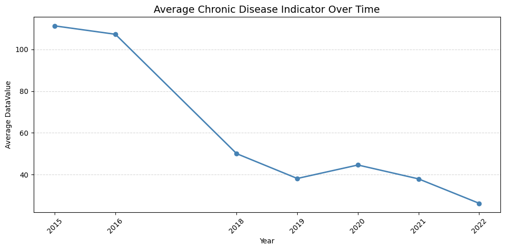

```python
# Line chart: trend of average chronic disease indicator over time
year_avg = df_new.groupby("YearStart")["DataValue"].mean()

plt.figure(figsize=(10, 5))
plt.plot(year_avg.index, year_avg.values, marker='o', color='steelblue', linewidth=2)
plt.title("Average Chronic Disease Indicator Over Time", fontsize=14)
plt.xlabel("Year")
plt.ylabel("Average DataValue")
plt.xticks(year_avg.index, rotation=45)
plt.grid(axis='y', linestyle='--', alpha=0.5)
plt.tight_layout()
plt.show()
```

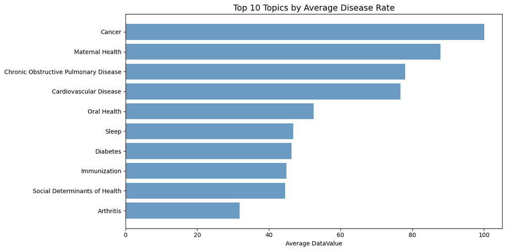

```python
# Bar chart: top 10 disease topics by average rate
topic_avg = df_new.groupby("Topic")["DataValue"].mean().sort_values(ascending=False).head(10)

plt.figure(figsize=(12, 6))
plt.barh(topic_avg.index[::-1], topic_avg.values[::-1], color='steelblue', alpha=0.8)
plt.title("Top 10 Topics by Average Disease Rate", fontsize=14)
plt.xlabel("Average DataValue")
plt.tight_layout()
plt.show()
```

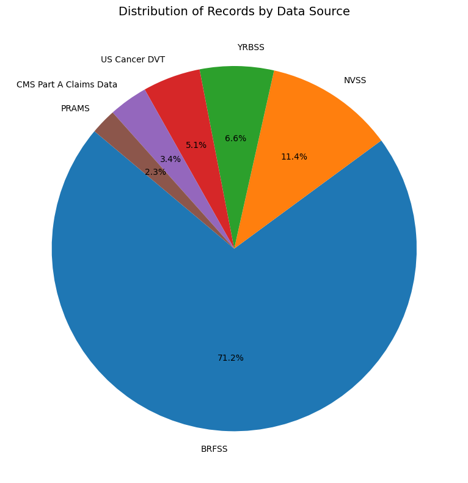

```python
# Pie chart: data source distribution
source_counts = df_new["DataSource"].value_counts().head(6)

plt.figure(figsize=(8, 8))
plt.pie(source_counts.values, labels=source_counts.index, autopct="%1.1f%%", startangle=140)
plt.title("Distribution of Records by Data Source", fontsize=14)
plt.tight_layout()
plt.show()
```

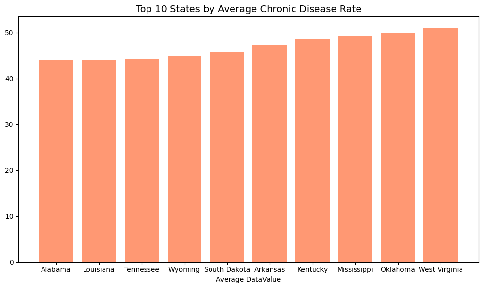

```python
# Bar chart: top 10 states by average disease rate (uses LocationDesc now properly kept)
state_avg = df_new.groupby("LocationDesc")["DataValue"].mean().sort_values(ascending=False).head(10)

plt.figure(figsize=(10, 6))
plt.bar(state_avg.index[::-1], state_avg.values[::-1], color='coral', alpha=0.8)
plt.title("Top 10 States by Average Chronic Disease Rate", fontsize=14)
plt.xlabel("Average DataValue")
plt.tight_layout()
plt.show()
```

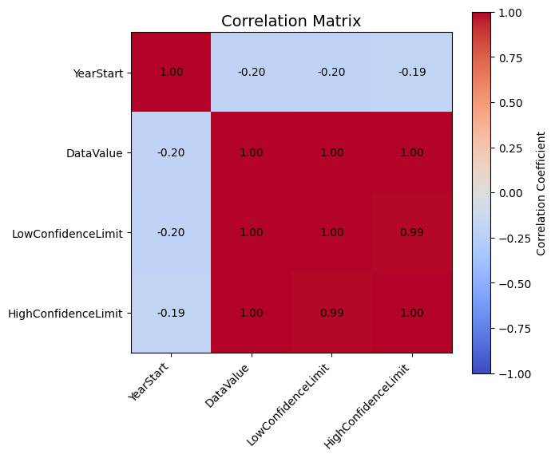

```python
import numpy as np

numeric_cols = df_new[["YearStart", "DataValue", "LowConfidenceLimit", "HighConfidenceLimit"]]
corr = numeric_cols.corr()

plt.figure(figsize=(7, 6))
im = plt.imshow(corr, cmap='coolwarm', vmin=-1, vmax=1)
plt.colorbar(im, label="Correlation Coefficient")
plt.xticks(range(len(corr.columns)), corr.columns, rotation=45, ha='right')
plt.yticks(range(len(corr.columns)), corr.columns)

# Annotate each cell with value
for i in range(len(corr)):
    for j in range(len(corr.columns)):
        plt.text(j, i, f"{corr.iloc[i, j]:.2f}", ha='center', va='center', fontsize=10, color='black')

plt.title("Correlation Matrix", fontsize=14)
plt.tight_layout()
plt.show()
```

#### Stats: Distribution of Disease Indicator Values

We examine the shape of the DataValue distribution using a histogram and KDE curve, then formally test for normality using the Shapiro-Wilk test.

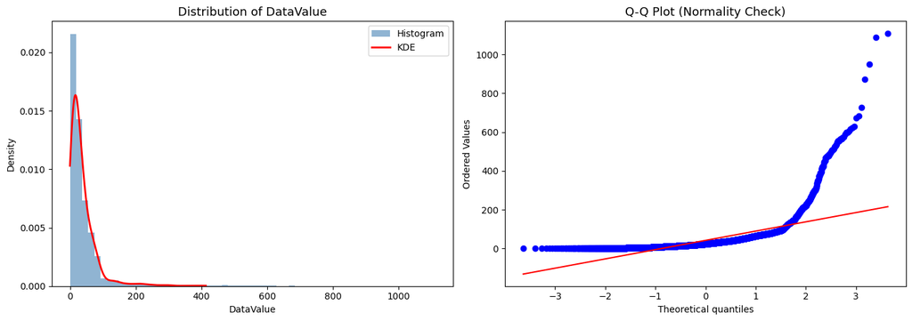

```
Shapiro-Wilk Test:
  Statistic: 0.5408
  P-value:   0.000000
  Conclusion: Data is NOT normally distributed (p < 0.05)
```

```python
from scipy import stats

sample = df_new["DataValue"].dropna().sample(5000, random_state=42)

fig, axes = plt.subplots(1, 2, figsize=(14, 5))

# Histogram + KDE
axes[0].hist(sample, bins=60, density=True, alpha=0.6, color='steelblue', label='Histogram')
kde_x = np.linspace(sample.min(), sample.quantile(0.99), 300)
kde = stats.gaussian_kde(sample)
axes[0].plot(kde_x, kde(kde_x), color='red', linewidth=2, label='KDE')
axes[0].set_title("Distribution of DataValue", fontsize=13)
axes[0].set_xlabel("DataValue")
axes[0].set_ylabel("Density")
axes[0].legend()

# Q-Q plot
stats.probplot(sample, dist="norm", plot=axes[1])
axes[1].set_title("Q-Q Plot (Normality Check)", fontsize=13)

plt.tight_layout()
plt.show()

# Shapiro-Wilk test (on smaller sample — test requires < 5000)
stat_val, p_val = stats.shapiro(sample[:500])
print(f"Shapiro-Wilk Test:")
print(f"  Statistic: {stat_val:.4f}")
print(f"  P-value:   {p_val:.6f}")
print(f"  Conclusion: {'Data is NOT normally distributed (p < 0.05)' if p_val < 0.05 else 'Data appears normally distributed (p >= 0.05)'}")
```

The histogram and Q-Q plot reveal whether disease indicator values follow a normal distribution. The data is right-skewed due to outliers (e.g., very high rates in specific subpopulations). The Shapiro-Wilk test provides a formal statistical confirmation of this.

#### Statistical Analysis 2: Hypothesis Test — Has Disease Rate Changed Over Time?

We use a Welch's two-sample t-test (does not assume equal variance).

```
Years in dataset: [np.int64(2015), np.int64(2016), np.int64(2018), np.int64(2019), np.int64(2020), np.int64(2021), np.int64(2022)]
Splitting at year: 2019

=== Welch's Two-Sample T-Test ===
  Early period (< 2019)  — Mean: 98.9513, N: 11,246
  Late period  (≥ 2019) — Mean: 37.5270, N: 177,639
  T-statistic: 43.5205
  P-value:     0.000000
  Conclusion:  Reject H₀ — significant difference found (p < 0.05)
```

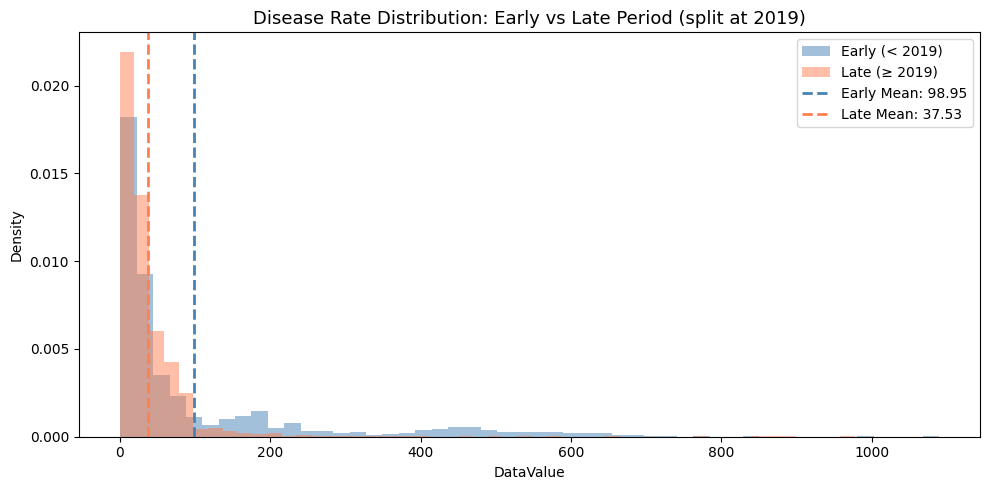

```python
# Dynamically find the midpoint year to split the data
years = sorted(df_new["YearStart"].dropna().unique())
split_year = years[len(years) // 2]
print(f"Years in dataset: {years}")
print(f"Splitting at year: {split_year}\n")

early = df_new[df_new["YearStart"] < split_year]["DataValue"].dropna()
late  = df_new[df_new["YearStart"] >= split_year]["DataValue"].dropna()

# Welch's t-test
t_stat, p_val = stats.ttest_ind(early, late, equal_var=False)

print("=== Welch's Two-Sample T-Test ===")
print(f"  Early period (< {split_year})  — Mean: {early.mean():.4f}, N: {len(early):,}")
print(f"  Late period  (≥ {split_year}) — Mean: {late.mean():.4f}, N: {len(late):,}")
print(f"  T-statistic: {t_stat:.4f}")
print(f"  P-value:     {p_val:.6f}")
print(f"  Conclusion:  {'Reject H₀ — significant difference found (p < 0.05)' if p_val < 0.05 else 'Fail to reject H₀ — no significant difference (p ≥ 0.05)'}")

# Visualize the two distributions
n_early = min(3000, len(early))
n_late  = min(3000, len(late))

plt.figure(figsize=(10, 5))
plt.hist(early.sample(n_early, random_state=1), bins=50, alpha=0.5, density=True, color='steelblue', label=f'Early (< {split_year})')
plt.hist(late.sample(n_late, random_state=1),   bins=50, alpha=0.5, density=True, color='coral',     label=f'Late (≥ {split_year})')
plt.axvline(early.mean(), color='steelblue', linestyle='--', linewidth=2, label=f'Early Mean: {early.mean():.2f}')
plt.axvline(late.mean(),  color='coral',     linestyle='--', linewidth=2, label=f'Late Mean: {late.mean():.2f}')
plt.title(f"Disease Rate Distribution: Early vs Late Period (split at {split_year})", fontsize=13)
plt.xlabel("DataValue")
plt.ylabel("Density")
plt.legend()
plt.tight_layout()
plt.show()
```

The t-test tells us whether the shift in average disease rates across the two time periods is statistically meaningful or could be due to random variation. A p-value below 0.05 means we have strong evidence of a real change in public health outcomes over this period.

#### Statistical Analysis 3: Confidence Intervals by Disease Topic

We plot the mean `DataValue` for the top 8 disease topics with 95% confidence intervals using the existing `LowConfidenceLimit` and `HighConfidenceLimit` columns.

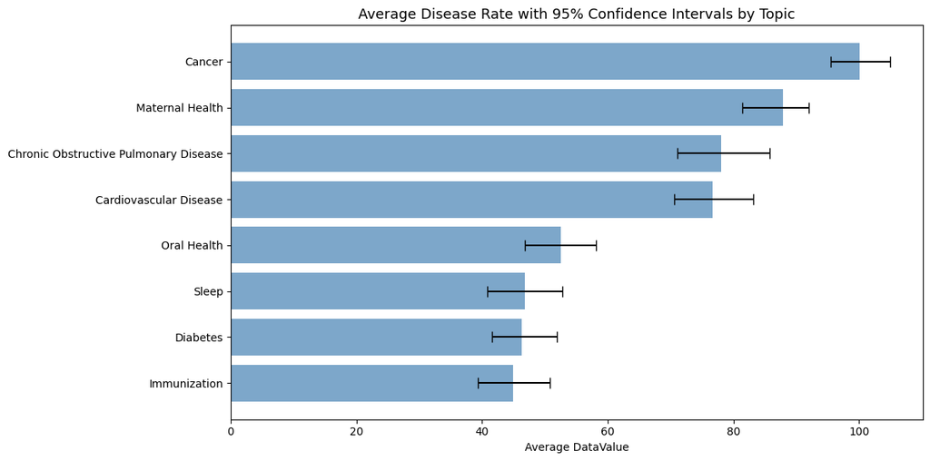

```
Topic statistics summary:
                                Topic       low       mean       high
                               Cancer 95.438094 100.082109 104.919772
                      Maternal Health 81.407833  87.884667  91.956667
Chronic Obstructive Pulmonary Disease 71.045785  78.064393  85.811137
               Cardiovascular Disease 70.632053  76.656234  83.205102
                          Oral Health 46.811318  52.536645  58.081628
                                Sleep 40.848459  46.791040  52.786705
                             Diabetes 41.647236  46.335687  51.882345
                         Immunization 39.303071  44.907401  50.815986
```

```python
# Confidence intervals by topic
topic_stats = df_new.groupby("Topic").agg(
    mean=("DataValue", "mean"),
    low=("LowConfidenceLimit", "mean"),
    high=("HighConfidenceLimit", "mean")
).sort_values("mean", ascending=False).head(8).reset_index()

# Asymmetric error bars
lower_err = topic_stats["mean"] - topic_stats["low"]
upper_err = topic_stats["high"] - topic_stats["mean"]
errors = [lower_err, upper_err]

plt.figure(figsize=(12, 6))
plt.barh(topic_stats["Topic"][::-1], topic_stats["mean"][::-1],
         xerr=[lower_err[::-1], upper_err[::-1]],
         capsize=5, color='steelblue', alpha=0.7, ecolor='black')
plt.title("Average Disease Rate with 95% Confidence Intervals by Topic", fontsize=13)
plt.xlabel("Average DataValue")
plt.tight_layout()
plt.show()

print("Topic statistics summary:")
print(topic_stats[["Topic", "low", "mean", "high"]].to_string(index=False))
```

The confidence intervals show the precision of disease rate estimates for each topic. Wider intervals indicate more variability or fewer data points for that disease category. Topics with non-overlapping confidence intervals are statistically distinguishable from each other.

## Advanced Analysis (Optional)

#### Linear Regression — Disease Rate Trend Over Time

We fit a linear regression model to quantify whether disease rates are increasing or decreasing over time.

```
=== Linear Regression: DataValue ~ YearStart ===
  Slope:     -12.6574  (change per year)
  Intercept: 25611.0404
  R²:        0.8651
  P-value:   0.002388
  Trend:     Decreasing over time
```

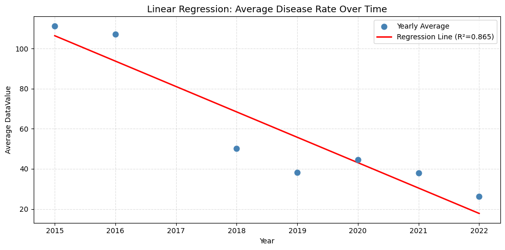

```python
from scipy.stats import linregress

year_avg = df_new.groupby("YearStart")["DataValue"].mean().reset_index()

slope, intercept, r_value, p_value, std_err = linregress(year_avg["YearStart"], year_avg["DataValue"])

print("=== Linear Regression: DataValue ~ YearStart ===")
print(f"  Slope:     {slope:.4f}  (change per year)")
print(f"  Intercept: {intercept:.4f}")
print(f"  R²:        {r_value**2:.4f}")
print(f"  P-value:   {p_value:.6f}")
print(f"  Trend:     {'Increasing' if slope > 0 else 'Decreasing'} over time")

# Plot
x_line = np.linspace(year_avg["YearStart"].min(), year_avg["YearStart"].max(), 100)
y_line = slope * x_line + intercept

plt.figure(figsize=(10, 5))
plt.scatter(year_avg["YearStart"], year_avg["DataValue"], color='steelblue', s=60, zorder=5, label='Yearly Average')
plt.plot(x_line, y_line, color='red', linewidth=2, label=f'Regression Line (R²={r_value**2:.3f})')
plt.title("Linear Regression: Average Disease Rate Over Time", fontsize=13)
plt.xlabel("Year")
plt.ylabel("Average DataValue")
plt.legend()
plt.grid(linestyle='--', alpha=0.4)
plt.tight_layout()
plt.show()
```

**Interpretation:** The slope of the regression line tells us the average annual change in disease rates. R² indicates how well year alone explains the variation. A statistically significant p-value (< 0.05) means the time trend is real and not due to chance.